# RANDOM FORESTS FOR IMPUTATION

Marco R. Steenbergen

steenbergen@ipz.uzh.ch

University of Zurich

July 28, 2025

# Basics of Missing Data

## The Bane of the Social Scientist’s Existence

- Missing data are a common occurrence in social science data analysis.
- They are common in survey research due to **non-response**.
- In archival work, they occur as well because reporting is not always complete.

## Missing Data Patterns

- Missing data patterns show how often and where missing data occur.
- This is generally a key step for understanding missingness.

## Example

- Variables
- Plot1
- Cases
- Plot2

```r
library(naniar)
library(rio)
world <- import("Data/world22.xlsx")
gg_miss_var(world, show_pct = TRUE)
```

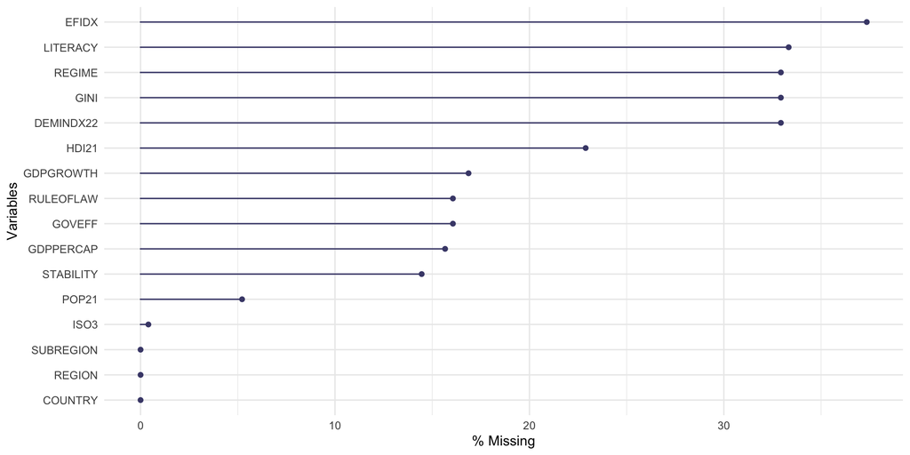

```r
gg_miss_case(world, order_cases = TRUE)
```

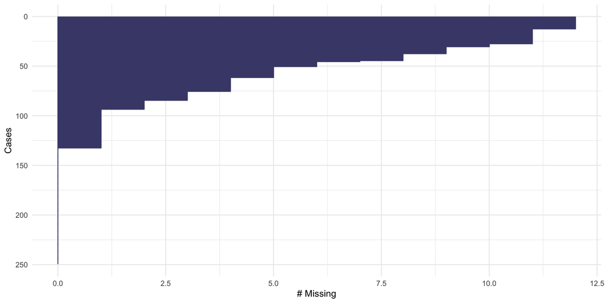

## Missing Data Mechanisms

- Missing data mechanisms describe how the missing data were generated.
- Generally, three mechanisms are identified (e.g., Rubin 1976).
  1. **Missing Completely at Random** (MCAR): Missing values arise by chance; no biases are introduced through missingness but efficiency suffers.
  2. **Missingness at Random** (MAR): Missing values are driven by covariates that may also drive the outcome of interest; biases are introduced and efficiency suffers.
  3. **Missingess Not at Random** (MNR): Missing values depend on the values of the outcome of interest; biases are introduced and efficiency suffers.

# Traditional Approaches for Missing Data

## Listwise Deletion

- A.k.a. complete case analysis.
- We drop all cases that have any missingness on the variables of interest.
- Unproblematic under MCAR, aside from efficiency loss.
- Bound to induce bias under MAR and MNR.

## Hot Deck Imputation

- The canonical reference is Ford (1983).
- Assuming MAR, we substitute the value of the nearest neighbor in terms of a set of covariates.
- This is what we have emulated using kNN.

## Parametric Approaches

- EM algorithm (Dempster, Laird, and Rubin 1977).
- Bayesian imputation (Rubin 1987).
- Multiple Imputation with Chained Equations (Van Buuren 2018).
- These work quite nicely but
  - Strong assumptions are needed
  - Missingness should not be too great

# Imputation Using Machine Learning

## Why Machine Learning for Missing Data?

- Non-parametric models.
- Capable of learning complex interplay of covariates.
- Tend to work well even when the amount of missing data is large.

## Random Forests

- Syntax1
- Results1
- Syntax2

```r
library(missForest)
library(tidyverse)
work <- world |>
  select(-c(COUNTRY, ISO3, REGION, SUBREGION, REGIME))
world_rf_imp <- missForest(work)
print(world_rf_imp$OOBerror)
```

```
    NRMSE
0.8691556
```

```r
world_rf_complete <- world_rf_imp$ximp
```

## References

Dempster, A. P., N. M. Laird, and D. B. Rubin. 1977. “Maximum Likelihood from Incomplete Data Via the *EM* Algorithm.” *Journal of the Royal Statistical Society: Series B (Methodological)* 39 (1): 1–22. https://doi.org/10.1111/j.2517-6161.1977.tb01600.x.

Ford, Barry L. 1983. “An Overview of Hot-Deck Procedures.” In *Incomplete Data in Sample Surveys, Vol. 2: Theory and Bibliographies*, edited by William Gregory Madow, Ingram Olkin, and Donald B. Rubin. New York London Paris [etc.]: Academic press.

Rubin, Donald B. 1976. “Inference and Missing Data.” *Biometrika* 63 (3): 581–92. https://doi.org/10.2307/2335739.

———. 1987. *Multiple Imputation for Nonresponse in Surveys*. Wiley Series in Probability and Mathematical Statistics Applied Probability and Statistics. New York: Wiley. https://doi.org/10.1002/9780470316696.

Van Buuren, Stef. 2018. *Flexible Imputation of Missing Data*. 2nd ed. Second edition. Boca Raton, Florida : CRC Press, [2019] : Chapman; Hall/CRC. https://doi.org/10.1201/9780429492259.